# 221109-Portfolio3_MachineLearning

Thomas Steinthal

2022-11-09

# The assignment

The Machine Learning assignment has 3 main parts: First we create a skeptical and an informed simulation, based on the meta-analysis. Second we build and test our machine learning pipeline on the simulated data. Second we apply the pipeline to the empirical data.

The report for the exam, thus, consists of the answer to all the following prompts: - Describe your machine learning pipeline. Produce a diagram of it to guide the reader (e.g. see Rybner et al 2022 Vocal markers of autism: Assessing the generalizability of ML models), and describe the different parts: data budgeting, data preprocessing, model choice and training, assessment of performance. - Briefly justify and describe your use of simulated data, and results from the pipeline on them. - Describe results from applying the ML pipeline to the empirical data and what can we learn from them.

Remember: plots are very very important to communicate your process and results.

## Part I - Simulating data

Use the meta-analysis reported in Parola et al (2020), create a simulated dataset with 100 matched pairs of schizophrenia and controls, each participant producing 10 repeated measures (10 trials with their speech recorded). for each of these “recordings” (data points) produce 10 acoustic measures: 6 from the meta-analysis, 4 with just random noise. Do the same for a baseline dataset including only 10 noise variables. Tip: see the slides for the code.

```r
#Simulating the dataset
set.seed(122)


n_pairs <- 100
measure<- 10
groups<-c('SZ','C')

#6 measures from
pitch_variability<-c(-.55,-1.06,-.01)
speech_rate<-c(-.75,-1.51,.04)
pause_duration<-c(1.89,.72,3.21) #Big effect size!
pause_number<-c(.05,-1.23,1.13) #Very high p-value
prop_of_spoken_time<-c(-1.26,-2.26,-0.25)
pitch_mean<-c(.25,-.72,1.3) #Very high p-value

#Random-noise
r1<-c(0,1)


sdf<-tibble(
  ID=rep(1:measure, each = 20),
  Trial=rep(1:10, each = 2, times = 10),
  Diagnosis=rep(groups, times=n_pairs))
```

```r
InformedMean<-c(-.55,-.75,1.89,.05,-1.26,.25,0,0,0,0)
base_mean<-rep(0,10)
indSD<-1
MeaSD<-0.5
Err<-.2


#Creating the datasets
for(i in seq(10)){
  meta_df<-tibble(
    ID=seq(n_pairs),
    Eff=rnorm(n_pairs,InformedMean[i],indSD),
    var=paste0('v',i)
  )
  base_df<-tibble(
    ID=seq(n_pairs),
    Eff=rnorm(n_pairs,base_mean[i],indSD),
    var=paste0('v',i)
  )
  if (i == 1) {
    meta_df_true <- meta_df
    base_df_true <- base_df #Little...
  }
  else{
    meta_df_true <- rbind(meta_df_true, meta_df)
    base_df_true <- rbind(base_df_true,base_df) #... by little
  }

}
```

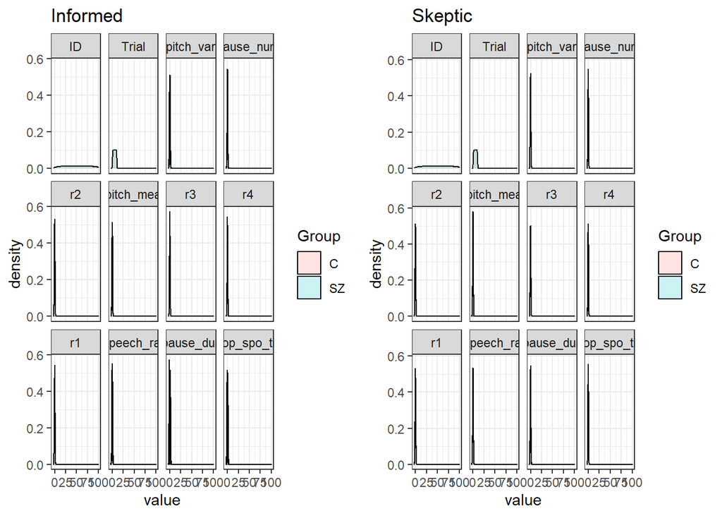

```r
d_trial <- tibble(expand_grid(ID=seq(n_pairs), Trial = seq(measure), Group = groups))

meta_df <- merge(meta_df_true,d_trial)
base_df <- merge(base_df_true,d_trial)

for (i in seq(nrow(meta_df))){ #Simulate data
  meta_df$measurement[i] <- ifelse(meta_df$Group[i] == 'SZ',
                                   rnorm(1,rnorm(1, meta_df$Eff[i]/2, MeaSD), Err),
                                   rnorm(1,rnorm(1, (-meta_df$Eff[i])/2, MeaSD), Err))
  base_df$measurement[i] <- ifelse(base_df$Group[i] == 'SZ',
                                   rnorm(1,rnorm(1, base_df$Eff[i]/2, MeaSD), Err),
                                   rnorm(1,rnorm(1, (-base_df$Eff[i])/2, MeaSD), Err))
}


meta_df <-  meta_df %>%
  mutate(Eff = NULL) %>%
  pivot_wider(names_from = var,
              values_from = measurement)
base_df <- base_df %>%
  mutate(Eff = NULL) %>%
  pivot_wider(names_from = var,
              values_from = measurement)

nam<-c('pitch_var', 'speech_rat', 'pause_dur', 'pause_num', 'prop_spo_tim', 'pitch_mea','r1','r2','r3','r4')

meta_df <- meta_df %>%  #The names seemed to be off which is why we made this little trick
  rename('pitch_var' = v1,
         'speech_rat' = v2,
         'pause_dur' = v3,
         'pause_num' = v4,
         'prop_spo_tim' = v5,
         'pitch_mea' = v6,
         'r1' = v7,
         'r2' = v8,
         'r3' = v9,
         'r4' = v10)

base_df <- base_df %>%
  rename('pitch_var' = v1,
         'speech_rat' = v2,
         'pause_dur' = v3,
         'pause_num' = v4,
         'prop_spo_tim' = v5,
         'pitch_mea' = v6,
         'r1' = v7,
         'r2' = v8,
         'r3' = v9,
         'r4' = v10)


#PLOTTTING
library(ggplot2)
library(reshape2)
plot_meta_df <- melt(meta_df) #Assessing quality
meta_plot <- plot_meta_df %>%
  group_by(Group) %>%
  ggplot(aes(x = value, fill = Group)) +
  geom_density(alpha = 0.2) +
  facet_wrap(~variable) +
  theme_bw() +
  ggtitle('Informed')

plot_base_df <- melt(base_df)
base_plot <- plot_base_df %>%
  group_by(Group) %>%
  ggplot(aes(x = value, fill = Group)) +
  geom_density(alpha = 0.2) +
  facet_wrap(~variable) +
  theme_bw() +
  ggtitle('Skeptic')

library(gridExtra)
grid.arrange(meta_plot, base_plot, ncol = 2)
```

## Part II - ML pipeline on simulated data

On the two simulated datasets (separately) build a machine learning pipeline: i) create a data budget (e.g. balanced training and test sets); ii) pre-process the data (e.g. scaling the features); iii) fit and assess a classification algorithm on the training data (e.g. Bayesian multilevel logistic regression); iv) assess performance on the test set; v) discuss whether performance is as expected and feature importance is as expected.

Bonus question: replace the bayesian multilevel regression with a different algorithm, e.g. SVM or random forest (but really, anything you’d like to try).

```r
meta_df <- meta_df %>%
  mutate(ID = as.factor(ID),
         Trial = as.factor(Trial))

base_df <- base_df %>%
  mutate(ID = as.factor(ID),
         Trial = as.factor(Trial))


Test_ID <- sample(seq(n_pairs, 20))

train_meta <- meta_df %>% subset((ID %in% Test_ID))
test_meta <- meta_df %>% subset(!ID %in% Test_ID)


Test_ID <- sample(seq(n_pairs, 20))

train_base <- base_df %>% subset((ID %in% Test_ID))
test_base <- base_df %>% subset(!ID %in% Test_ID)
```

```r
#Preparing the model
rec_meta <- train_meta %>%
  recipe(Group ~ . ) %>%
  step_scale(all_numeric() ) %>%
  step_center(all_numeric() ) %>%
  prep(training = train_meta, retain = TRUE)

rec_base <- train_base %>%  #Also for noice-set
  recipe(Group ~ . ) %>%
  step_scale(all_numeric() ) %>%
  step_center(all_numeric() ) %>%
  prep(training = train_base, retain = TRUE)

train_meta_s <- juice(rec_meta)
test_meta_s <- bake(rec_meta, new_data = test_meta)

train_base_s <- juice(rec_base)
test_base_s <- bake(rec_base, new_data = test_base) #Bakeries running
```

```r
train_meta_f <- train_meta_s[-c(1:2)]

train_base_f <- train_base_s[-c(1:2)]

pacman::p_load(rstanarm, randomForest, xgboost, kernlab, dplyr)

#Using all machines on both datasets

meta_stan <- logistic_reg() %>%
  set_mode("classification") %>%
  set_engine("glm") %>%
  fit(Group ~ . , data = train_meta_f)

meta_rf <- rand_forest() %>%
  set_mode("classification") %>%
  set_engine("randomForest") %>%
  fit(Group ~ . , data = train_meta_f)

meta_boost <- boost_tree() %>%
  set_mode("classification") %>%
  set_engine("xgboost") %>%
  fit(Group ~ . , data = train_meta_f)

meta_svm <- svm_rbf() %>%
  set_mode("classification") %>%
  set_engine("kernlab") %>%
  fit(Group ~ . , data = train_meta_f)

base_stan <- logistic_reg() %>%
  set_mode("classification") %>%
  set_engine("glm") %>%
  fit(Group ~ . , data = train_base_f)

base_rf <- rand_forest() %>%
  set_mode("classification") %>%
  set_engine("randomForest") %>%
  fit(Group ~ . , data = train_base_f)

base_boost <- boost_tree() %>%
  set_mode("classification") %>%
  set_engine("xgboost") %>%
  fit(Group ~ . , data = train_base_f)

base_svm <- svm_rbf() %>%
  set_mode("classification") %>%
  set_engine("kernlab") %>%
  fit(Group ~ . , data = train_base_f)
```

```r
#How did it do?
meta_results <- test_meta_s %>%
as_tibble() %>%
  mutate(
    log_class = predict(meta_stan, new_data = test_meta_s) %>%
      pull(.pred_class),
    log_prob =  predict(meta_stan, new_data = test_meta_s, type = "prob") %>%
      pull(.pred_SZ),
svm_class = predict(meta_svm, new_data = test_meta_s) %>%
  pull(.pred_class),
svm_prob = predict(meta_svm, new_data = test_meta_s, type = "prob") %>%
  pull(.pred_SZ),
rf_class = predict (meta_rf, new_data = test_meta_s) %>%
  pull(.pred_class),
rf_prob = predict(meta_rf, new_data = test_meta_s, type = "prob") %>%
pull(.pred_SZ),
boost_class = predict(meta_boost, new_data = test_meta_s) %>%
  pull(.pred_class),
boost_prob = predict(meta_boost, new_data = test_meta_s, type = "prob") %>%
  pull(.pred_SZ)
)

#Nice data
logi_pred_meta <- metrics(meta_results, truth = Group, estimate = log_class) %>%
  knitr::kable()
vectormachine_pred_meta <- metrics(meta_results, truth = Group, estimate = svm_class) %>%
  knitr::kable()
randomforest_pred_meta <- metrics(meta_results, truth = Group, estimate = rf_class) %>%
  knitr::kable()
boost_pred_meta <- metrics(meta_results, truth = Group, estimate = boost_class) %>%
  knitr::kable()

pacman::p_load(caret)

#Cutting out the scores we need
CM_sim_log <- confusionMatrix(meta_results$log_class, meta_results$Group, mode = "everything")
CM_sim_svm <- confusionMatrix(meta_results$svm_class, meta_results$Group, mode = "everything")
CM_sim_rf <- confusionMatrix(meta_results$rf_class, meta_results$Group, mode = "everything")
CM_sim_bo <- confusionMatrix(meta_results$boost_class, meta_results$Group, mode = "everything")

#Here F1-score
CM_sim <- c(CM_sim_log$byClass[7], CM_sim_svm$byClass[7], CM_sim_rf$byClass[7],CM_sim_bo$byClass[7])

#And plotting
meta_plot <- tibble(
  engine = c("Log_Reg", "Ran_For", "Boo_Tre", "Vec_Mac"),
  accuracy = c(logi_pred_meta[3], randomforest_pred_meta[3], boost_pred_meta[3], vectormachine_pred_meta [3]),
  kappa = c(logi_pred_meta[4], randomforest_pred_meta[4], boost_pred_meta[4], vectormachine_pred_meta [4])
) %>%
  mutate(F1 = CM_sim)
```

```r
#All again for noise
base_results <- test_base_s %>%
as_tibble() %>%
  mutate(
    log_class = predict(base_stan, new_data = test_base_s) %>%
      pull(.pred_class),
    log_prob =  predict(base_stan, new_data = test_base_s, type = "prob") %>%
      pull(.pred_SZ),
svm_class = predict(base_svm, new_data = test_base_s) %>%
  pull(.pred_class),
svm_prob = predict(base_svm, new_data = test_base_s, type = "prob") %>%
  pull(.pred_SZ),
rf_class = predict (base_rf, new_data = test_base_s) %>%
  pull(.pred_class),
rf_prob = predict(base_rf, new_data = test_base_s, type = "prob") %>%
pull(.pred_SZ),
boost_class = predict(base_boost, new_data = test_base_s) %>%
  pull(.pred_class),
boost_prob = predict(base_boost, new_data = test_base_s, type = "prob") %>%
  pull(.pred_SZ)
)

logi_pred_base <- metrics(base_results, truth = Group, estimate = log_class) %>%
  knitr::kable()
vectormachine_pred_base <- metrics(base_results, truth = Group, estimate = svm_class) %>%
  knitr::kable()
randomforest_pred_base <- metrics(base_results, truth = Group, estimate = rf_class) %>%
  knitr::kable()
boost_pred_base<- metrics(base_results, truth = Group, estimate = boost_class) %>%
  knitr::kable()

CM_sim_log <- confusionMatrix(base_results$log_class, base_results$Group, mode = "everything")
CM_sim_svm <- confusionMatrix(base_results$svm_class, base_results$Group, mode = "everything")
CM_sim_rf <- confusionMatrix(base_results$rf_class, base_results$Group, mode = "everything")
CM_sim_bo <- confusionMatrix(base_results$boost_class, base_results$Group, mode = "everything")

CM_sim <- c(CM_sim_log$byClass[7], CM_sim_svm$byClass[7], CM_sim_rf$byClass[7],CM_sim_bo$byClass[7])

base_plot <- tibble(
  engine = c("Log_Reg", "Ran_For", "Boo_Tre", "Vec_Mac"),
  accuracy = c(logi_pred_base[3], randomforest_pred_base[3], boost_pred_base[3], vectormachine_pred_base[3]),
  kappa = c(logi_pred_base[4], randomforest_pred_base[4], boost_pred_base[4], vectormachine_pred_base[4])
) %>%
  mutate(F1 = CM_sim)
```

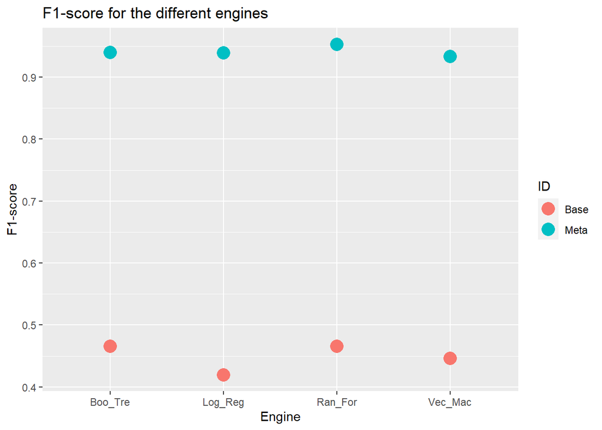

```r
#Cleaning data
meta_plot <- meta_plot %>%
  mutate(accuracy = parse_number(accuracy),
         kappa = parse_number(kappa)
         )

base_plot <- base_plot %>%
  mutate(accuracy = parse_number(accuracy),
         kappa = parse_number(kappa)
         )

#Binding and plotting
plot_df <- rbind(meta_plot, base_plot)
plot_df <- plot_df %>%
  mutate(ID = rep(c("Meta", "Base"), each = 4))

ggplot(plot_df, aes(engine, F1, color = ID))+
  geom_point(size = 5)+
  xlab("Engine")+
  ylab("F1-score")+
  ggtitle("F1-score for the different engines")
```

## Part III - Applying the ML pipeline to empirical data

Download the empirical dataset from brightspace and apply your ML pipeline to the new data, adjusting where needed. Warning: in the simulated dataset we only had 10 features, now you have many more! Such is the life of the ML practitioner. Consider the impact a higher number of features will have on your ML inference, and decide whether you need to cut down the number of features before running the pipeline (or alternatively expand the pipeline to add feature selection).

Data: https://www.dropbox.com/s/7ky1axvea33lgye/Ass3_empiricalData1.csv?dl=0

```r
d<-read_csv('Ass3_empiricalData1.csv')
set.seed(1)
# Split data by Diagnosis
d_scz <- d %>%
  filter(Diagnosis != "CT")

d_ct <- d %>%
  filter(Diagnosis != "SCZ")

test_emp_ct <- d_ct[d_ct$PatID %in% sample(unique(d_ct$PatID), 23),]
train_emp_ct <- d_ct[!d_ct$PatID %in% sample(unique(d_ct$PatID), 23),]


test_emp_scz <- d_scz[d_scz$PatID %in% sample(unique(d_scz$PatID), 18),]
train_emp_scz <- d_scz[!d_scz$PatID %in% sample(unique(d_scz$PatID), 18),]

test_emp <- rbind(test_emp_ct, test_emp_scz)
train_emp <- rbind(train_emp_ct, train_emp_scz)

# NOW THE DATA IS SPLIT
```

```r
#Same pipeline as before
rec_emp <- train_emp %>%
  recipe(Diagnosis ~ . ) %>%
  step_scale(all_numeric() ) %>%
  step_center(all_numeric() ) %>%
  prep(training = train_emp, retain = TRUE)


train_emp_s <- juice(rec_emp)
test_emp_s <- bake(rec_emp, new_data = test_emp)
```

```r
train_emp_f <- train_emp_s[-c(1:6)] %>%
  mutate( Diagnosis = as.factor(Diagnosis))

pacman::p_load(rstanarm, randomForest, xgboost, kernlab, dplyr)

#Briefly testing all 4 machines

emp_stan <- logistic_reg() %>%
  set_mode("classification") %>%
  set_engine("glm") %>%
  fit(Diagnosis ~ . , data = train_emp_f)
emp_rf <- rand_forest() %>%
  set_mode("classification") %>%
  set_engine("randomForest") %>%
  fit(Diagnosis ~ . , data = train_emp_f)

emp_boost <- boost_tree() %>%
  set_mode("classification") %>%
  set_engine("xgboost") %>%
  fit(Diagnosis ~ . , data = train_emp_f)

emp_svm <- svm_rbf() %>%
  set_mode("classification") %>%
  set_engine("kernlab") %>%
  fit(Diagnosis ~ . , data = train_emp_f)
```

```r
#And predicitng
emp_results <- test_emp_s %>%
as_tibble() %>%
  mutate(
    log_class = predict(emp_stan, new_data = test_emp_s) %>%
      pull(.pred_class),
    log_prob =  predict(emp_stan, new_data = test_emp_s, type = "prob") %>%
      pull(.pred_SCZ),
svm_class = predict(emp_svm, new_data = test_emp_s) %>%
  pull(.pred_class),
svm_prob = predict(emp_svm, new_data = test_emp_s, type = "prob") %>%
  pull(.pred_SCZ),
rf_class = predict (emp_rf, new_data = test_emp_s) %>%
  pull(.pred_class),
rf_prob = predict(emp_rf, new_data = test_emp_s, type = "prob") %>%
pull(.pred_SCZ),
boost_class = predict(emp_boost, new_data = test_emp_s) %>%
  pull(.pred_class),
boost_prob = predict(emp_boost, new_data = test_emp_s, type = "prob") %>%
  pull(.pred_SCZ)
)
```

```r
logi_pred_emp <- metrics(emp_results, truth = Diagnosis, estimate = log_class) %>%
  knitr::kable()
svm_pred_emp <- metrics(emp_results, truth = Diagnosis, estimate = svm_class) %>%
  knitr::kable()
rf_pred_emp <- metrics(emp_results, truth = Diagnosis, estimate = rf_class) %>%
  knitr::kable()
boost_pred_emp <- metrics(emp_results, truth = Diagnosis, estimate = boost_class) %>%
  knitr::kable()

CM_sim_log <- confusionMatrix(emp_results$log_class, emp_results$Diagnosis, mode = "everything")
CM_sim_svm <- confusionMatrix(emp_results$svm_class, emp_results$Diagnosis, mode = "everything")
CM_sim_rf <- confusionMatrix(emp_results$rf_class, emp_results$Diagnosis, mode = "everything")
CM_sim_bo <- confusionMatrix(emp_results$boost_class, emp_results$Diagnosis, mode = "everything")

CM_sim <- c(CM_sim_log$byClass[7], CM_sim_svm$byClass[7], CM_sim_rf$byClass[7],CM_sim_bo$byClass[7])

emp_plot <- tibble(
  engine = c("Log_Reg", "Ran_For", "Boo_Tre", "Vec_Mac"),
  accuracy = c(logi_pred_emp[3], rf_pred_emp[3], boost_pred_emp[3], svm_pred_emp[3]),
  kappa = c(logi_pred_emp[4], rf_pred_emp[4], boost_pred_emp[4], svm_pred_emp[4])
) %>%
  mutate(F1 = CM_sim) #And all the fuzzle to get the F1-score
```

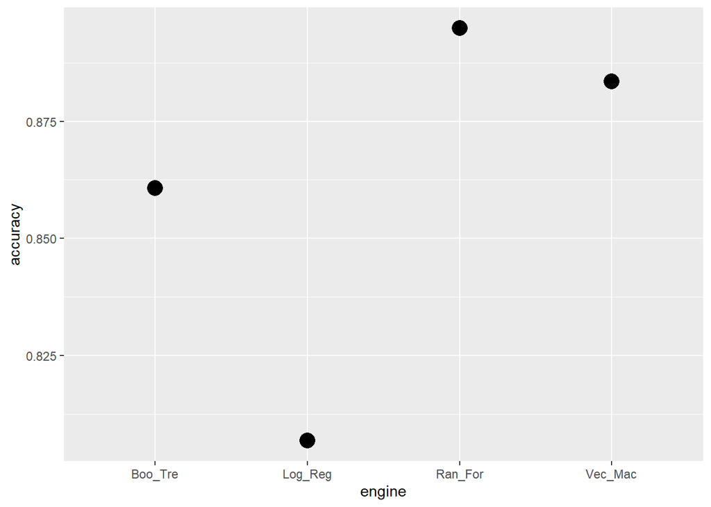

```r
emp_plot <- emp_plot %>%
  mutate(accuracy = parse_number(accuracy),
         kappa = parse_number(kappa)
         )

ggplot(emp_plot, aes(engine, accuracy))+
  geom_point(size = 5)
```

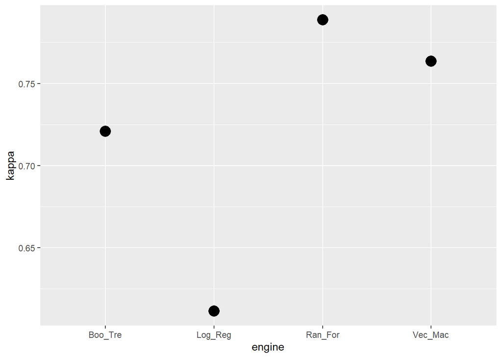

```r
ggplot(emp_plot, aes(engine, kappa))+
  geom_point(size = 5)
```

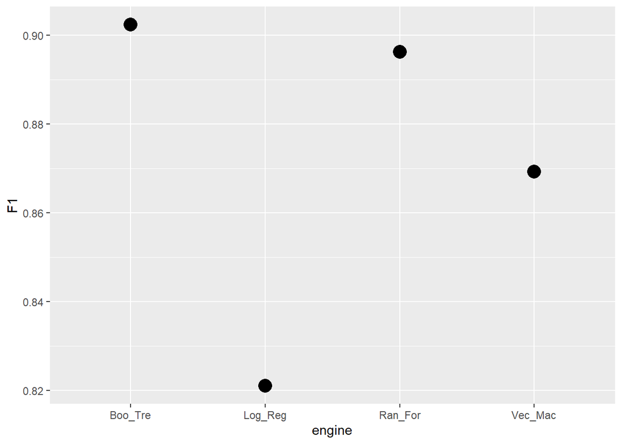

```r
ggplot(emp_plot, aes(engine, F1))+
  geom_point(size = 5)
```

```r
d<-read_csv('Ass3_empiricalData1.csv')
```

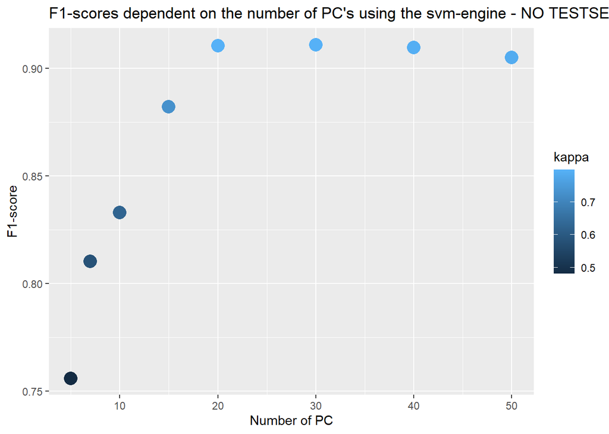

```r
###### FIRST SAMPLING - TAKING OUT THE FINAL TESTSET
set.seed(123)
pca_rec_j <- d %>%
  mutate(ID = 1:length(Diagnosis))

# Split data by Diagnosis
d_scz <- pca_rec_j %>%
  filter(Diagnosis != "CT")

d_ct <- pca_rec_j %>%
  filter(Diagnosis != "SCZ")

test_emp_ct <- d_ct[d_ct$ID %in% sample(unique(d_ct$ID), 162),]
train_emp_ct <- d_ct[!d_ct$ID %in% sample(unique(d_ct$ID), 162),]


test_emp_scz <- d_scz[d_scz$ID %in% sample(unique(d_scz$ID), 148),]
train_emp_scz <- d_scz[!d_scz$ID %in% sample(unique(d_scz$ID), 148),]

test_emp_pca <- rbind(test_emp_ct, test_emp_scz)
train_emp_pca <- rbind(train_emp_ct, train_emp_scz)


###### We save these datasets for later

d<-train_emp_pca
final_train <- d
final_test <- test_emp_pca

####DATASET IS NOW PREPARED FOR SPLIT AND TRAINING

set.seed(123)
pca_rec_j <- d %>%
  mutate(ID = 1:length(Diagnosis))

# Split data by Diagnosis
d_scz <- pca_rec_j %>%
  filter(Diagnosis != "CT")

d_ct <- pca_rec_j %>%
  filter(Diagnosis != "SCZ")

test_emp_ct <- d_ct[d_ct$ID %in% sample(unique(d_ct$ID), 162),]
train_emp_ct <- d_ct[!d_ct$ID %in% sample(unique(d_ct$ID), 162),]


test_emp_scz <- d_scz[d_scz$ID %in% sample(unique(d_scz$ID), 148),]
train_emp_scz <- d_scz[!d_scz$ID %in% sample(unique(d_scz$ID), 148),]

test_emp_pca <- rbind(test_emp_ct, test_emp_scz)
train_emp_pca <- rbind(train_emp_ct, train_emp_scz)


#Prepping
train_emp_pca<-train_emp_pca %>%
  select(Diagnosis, Duration_Praat:MeanTurnDur_Praat)


#Fucntion for simulating with x (nums) components
PCA<-function(nums) {
pca_rec <- recipe(~., data = train_emp_pca) %>%
  update_role(Diagnosis, new_role = "id") %>%
  step_normalize(all_predictors()) %>%
  step_pca(all_numeric_predictors(), num_comp = nums)

pca_prep <- prep(pca_rec, training = train_emp_pca)
pca_rec_j <- juice(pca_prep)

test_emp_s <- bake(pca_prep, new_data = test_emp)


## NOW THE DATA IS PREPROCESSED!

#Training a model
pca_rec_m <- svm_rbf() %>%
  set_mode("classification") %>%
  set_engine("kernlab") %>%
  fit(Diagnosis ~ . , data = pca_rec_j)


pca_res <- test_emp_s %>%
as_tibble() %>%
  mutate(
svm_class = predict(pca_rec_m, new_data = test_emp_s) %>%
  pull(.pred_class),
svm_prob = predict(pca_rec_m, new_data = test_emp_s, type = "prob") %>%
  pull(.pred_SCZ)
)

svm_pred_emp <- metrics(pca_res, truth = Diagnosis, estimate = svm_class) %>%
  knitr::kable()


pacman::p_load(caret)

CM<-confusionMatrix(pca_res$svm_class, pca_res$Diagnosis, mode = "everything")

#Reading off
emp_plot <- tibble(
  id = nums,
  engine = c("Vec_Mac"),
  accuracy = c(svm_pred_emp[3]),
  kappa = c(svm_pred_emp[4])
) %>%
  mutate(F1 = CM$byClass[7])

return(emp_plot)
}

emp_plot<-rbind(PCA(5),PCA(7),PCA(10),PCA(15),PCA(20), PCA(30), PCA(40), PCA(50))


emp_plot <- emp_plot %>%
  mutate(accuracy = parse_number(accuracy),
         kappa = parse_number(kappa)
         )


ggplot(emp_plot, aes(id,F1,colour = kappa))+
  geom_point(size = 5)+
  xlab("Number of PC")+
  ylab("F1-score")+
  ggtitle("F1-scores dependent on the number of PC's using the svm-engine - NO TESTSET USED YET")
```

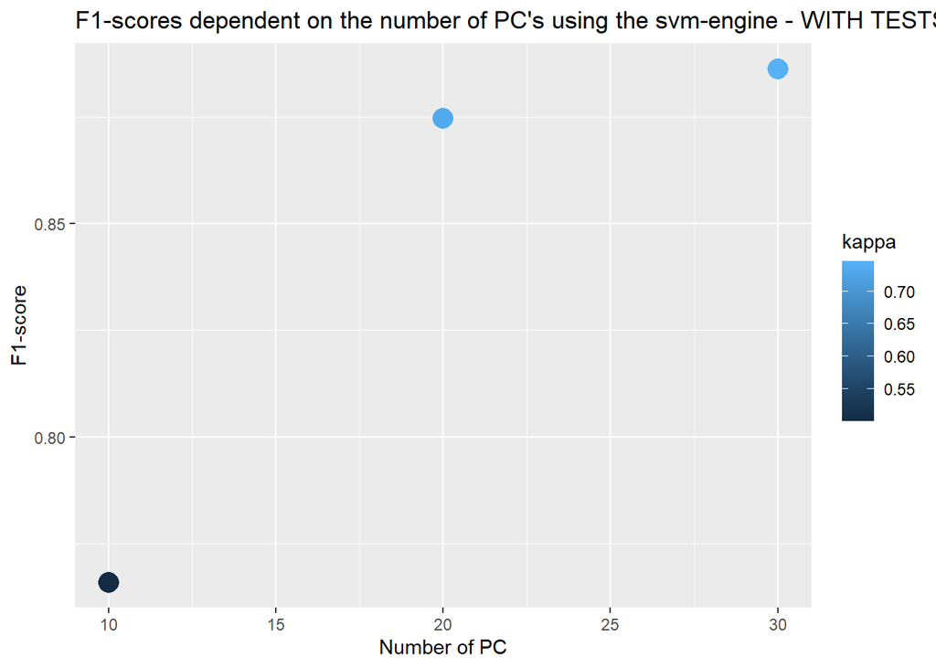

```r
### AND NOW WE HAVE THE FINAL TEST-SET LYING. We found that 20 PC was the most appropriate

#Prepping
final_train<-final_train %>%
  select(Diagnosis, Duration_Praat:MeanTurnDur_Praat)

PCA<-function(nums) {
pca_rec <- recipe(~., data = final_train) %>%
  update_role(Diagnosis, new_role = "id") %>%
  step_normalize(all_predictors()) %>%
  step_pca(all_numeric_predictors(), num_comp = nums)

pca_prep <- prep(pca_rec, training = final_train)
pca_rec_j <- juice(pca_prep)

test_emp_s <- bake(pca_prep, new_data = final_test)


## NOW THE DATA IS PREPROCESSED!

#Training a model
pca_rec_m <- svm_rbf() %>%
  set_mode("classification") %>%
  set_engine("kernlab") %>%
  fit(Diagnosis ~ . , data = pca_rec_j)


pca_res <- test_emp_s %>%
as_tibble() %>%
  mutate(
svm_class = predict(pca_rec_m, new_data = test_emp_s) %>%
  pull(.pred_class),
svm_prob = predict(pca_rec_m, new_data = test_emp_s, type = "prob") %>%
  pull(.pred_SCZ)
)

svm_pred_emp <- metrics(pca_res, truth = Diagnosis, estimate = svm_class) %>%
  knitr::kable()


pacman::p_load(caret)

CM<-confusionMatrix(pca_res$svm_class, pca_res$Diagnosis, mode = "everything")

#Reading off
emp_plot <- tibble(
  id = nums,
  engine = c("Vec_Mac"),
  accuracy = c(svm_pred_emp[3]),
  kappa = c(svm_pred_emp[4])
) %>%
  mutate(F1 = CM$byClass[7])

return(emp_plot)
}

emp_plot<-rbind(PCA(10),PCA(20), PCA(30)) #The 10 and 30 are mainly for comparison. We go with 20


emp_plot <- emp_plot %>%
  mutate(accuracy = parse_number(accuracy),
         kappa = parse_number(kappa)
         )


ggplot(emp_plot, aes(id,F1,colour = kappa))+
  geom_point(size = 5)+
  xlab("Number of PC")+
  ylab("F1-score")+
  ggtitle("F1-scores dependent on the number of PC's using the svm-engine - WITH TESTSET. We aimed for the 20 components based on our training")
```

```r
emp_plot
```

```
## # A tibble: 3 × 5
##      id engine  accuracy kappa    F1
##   <dbl> <chr>      <dbl> <dbl> <dbl>
## 1    10 Vec_Mac    0.752 0.501 0.766
## 2    20 Vec_Mac    0.868 0.735 0.875
## 3    30 Vec_Mac    0.874 0.746 0.886
```